# Multi-dataset replicability of genetics vs PD associations

```r
library(tidyverse)
library(reactable)
library(ggpubr)
```

# 1 Interaction `variant x PD`

## 1.1 Approach 1 - Clusters abundance

```r
approach1_interaction_raw_results <- list(
  DoD = read_tsv("output_DoD/Q1/01_lm_interaction_Variant.x.PD.tsv") %>% mutate(Dataset = "DoD"),
  NGRC = read_tsv("output_NGRC/Q1/01_lm_interaction_Variant.x.PD.tsv") %>% mutate(Dataset = "NGRC"),
  UAB = read_tsv("output_UAB/Q1/01_lm_interaction_Variant.x.PD.tsv") %>% mutate(Dataset = "UAB")
) %>%
  lapply(relocate, Dataset) %>%
  lapply(filter, grepl(":", term))
```

### 1.1.1 Significance based on Bonferroni-adjusted P-values

No interaction term was ever significant accounting for all independent tests as defined before ($N_{clusters} \times N_{indep.Variants}$).

```r
tmp <- lapply(approach1_interaction_raw_results, filter, p.adj_bonferroni < 0.1) %>%
  lapply(mutate_if, is.numeric, round, 4) %>%
  lapply(reactable, sortable = TRUE, filterable = TRUE)
```

```r
tmp$DoD
```

| Dataset | clusterName | variant | term | estimate | std.error | statistic | p.value | p.adj_bonferroni | significant |
| --- | --- | --- | --- | --- | --- | --- | --- | --- | --- |

```r
tmp$NGRC
```

| Dataset | clusterName | variant | term | estimate | std.error | statistic | p.value | p.adj_bonferroni | significant |
| --- | --- | --- | --- | --- | --- | --- | --- | --- | --- |

```r
tmp$UAB
```

| Dataset | clusterName | variant | term | estimate | std.error | statistic | p.value | p.adj_bonferroni | significant |
| --- | --- | --- | --- | --- | --- | --- | --- | --- | --- |

### 1.1.2 Conclusions of approach 1 (ClusterSum)

- Within dataset:
  - There were no Bonferroni-adjusted interaction associations
- Across datasets:
  - No overlap of the few associations marginally significant considering raw p-values.

## 1.2 Approach 2 - Regression of each microbe, followed by Microbe Set Enrichment analysis

### 1.2.1 LinDA association only

```r
approach2_interaction_linda <- list(
  DoD = read_tsv("output_DoD/Q1/02_LinDA_regression_dosage.x.PD_FullResults.tsv") %>% mutate(Dataset = "DoD"),
  NGRC = read_tsv("output_NGRC/Q1/02_LinDA_regression_dosage.x.PD_FullResults.tsv") %>% mutate(Dataset = "NGRC"),
  UAB = read_tsv("output_UAB/Q1/02_LinDA_regression_dosage.x.PD_FullResults.tsv") %>% mutate(Dataset = "UAB")
) %>%
  lapply(relocate, Dataset) %>%
  lapply(filter, grepl("interactionPD", covariate))
```

```r
tables_as_list <- approach2_interaction_linda %>%
  lapply(filter, padj < 0.1) %>%
  lapply(mutate_if, is.numeric, round, 4) %>%
  lapply(select, -lfcSE, -reject, -df, -covariate) %>%
  lapply(reactable, sortable = TRUE, filterable = TRUE)
```

```r
tables_as_list$DoD
```

| Dataset | variantName | taxon | baseMean | log2FoldChange | stat | pvalue | padj |
| --- | --- | --- | --- | --- | --- | --- | --- |
| DoD | chr4_89587189_T_G | s__Actinomyces_sp_ICM47 | 0.7312 | -1.874 | -4.0292 | 0.0001 | 0.0161 |
| DoD | chr4_89685975_C_G | s__Actinomyces_sp_ICM47 | 0.7921 | 1.666 | 3.5947 | 0.0003 | 0.0899 |
| DoD | chr4_89718364_G_T | s__Bifidobacterium_adolescentis | 1.687 | 2.5638 | 3.5434 | 0.0004 | 0.0545 |
| DoD | chr4_89718364_G_T | s__Gordonibacter_pamelaeae | 278.2769 | -1.4584 | -3.8481 | 0.0001 | 0.0336 |
| DoD | chr4_89723303_A_G | s__Bifidobacterium_adolescentis | 1.6794 | 2.5675 | 3.5263 | 0.0004 | 0.0581 |
| DoD | chr4_89723303_A_G | s__Gordonibacter_pamelaeae | 279.7973 | -1.4323 | -3.7554 | 0.0002 | 0.0485 |
| DoD | chr4_89761323_T_C | s__Bifidobacterium_adolescentis | 1.6229 | 2.6221 | 3.5561 | 0.0004 | 0.052 |
| DoD | chr4_89761323_T_C | s__Gordonibacter_pamelaeae | 283.3977 | -1.4483 | -3.7487 | 0.0002 | 0.0498 |

```r
tables_as_list$NGRC
```

| Dataset | variantName | taxon | baseMean | log2FoldChange | stat | pvalue | padj |
| --- | --- | --- | --- | --- | --- | --- | --- |
| NGRC | chr4_89716450_G_A | s__Pseudoflavonifractor_capillosus | 0.1791 | 1.4897 | 4.0891 | 0.0001 | 0.0155 |
| NGRC | chr4_89718364_G_T | s__Roseburia_faecis | 188.6152 | -3.595 | -3.3466 | 0.0009 | 0.0738 |
| NGRC | chr4_89718364_G_T | s__Ruminococcus_bromii | 71.3955 | -3.8334 | -3.3096 | 0.001 | 0.0738 |
| NGRC | chr4_89718364_G_T | s__Veillonella_dispar | 0.3611 | -2.203 | -4.0433 | 0.0001 | 0.0187 |
| NGRC | chr4_89718364_G_T | s__Veillonella_infantium | 0.1312 | -1.4141 | -3.6466 | 0.0003 | 0.044 |
| NGRC | chr4_89720189_T_C | s__Pseudoflavonifractor_capillosus | 0.1792 | 1.4973 | 4.1109 | 0.0001 | 0.0142 |
| NGRC | chr4_89723303_A_G | s__Roseburia_faecis | 188.8835 | -3.6028 | -3.3451 | 0.0009 | 0.0748 |
| NGRC | chr4_89723303_A_G | s__Ruminococcus_bromii | 71.4618 | -3.8391 | -3.3059 | 0.0011 | 0.0748 |
| NGRC | chr4_89723303_A_G | s__Veillonella_dispar | 0.3617 | -2.2113 | -4.0476 | 0.0001 | 0.0184 |
| NGRC | chr4_89723303_A_G | s__Veillonella_infantium | 0.1313 | -1.4182 | -3.6473 | 0.0003 | 0.0439 |

[output cut: 6 more lines]

```r
tables_as_list$UAB
```

| Dataset | variantName | taxon | baseMean | log2FoldChange | stat | pvalue | padj |
| --- | --- | --- | --- | --- | --- | --- | --- |
| UAB | chr4_89685975_C_G | s__Desulfovibrio_piger | 0.1046 | 1.5675 | 4.3257 | 0 | 0.0051 |

Are there cases where the same variant:PD interaction term is significantly associated with the same bacterium in more than one dataset?

```r
tmp <- approach2_interaction_linda %>%
  lapply(filter, padj < 0.1) %>%
  reduce(full_join, by = c("taxon", "variantName"))

associations_replic <- tmp[rowSums(is.na(select(tmp, contains("log2FoldChange")))) < 2,]

linda_intersection_also_nonsignif <- approach2_interaction_linda %>%
  lapply(filter, variantName %in% associations_replic$variantName, taxon %in% associations_replic$taxon) %>%
  reduce(rbind.data.frame) %>%
  mutate(alpha = ifelse(padj < 0.1, 1, 0.5))

reactable(linda_intersection_also_nonsignif)
```

| Dataset | variantName | covariate | taxon | baseMean | log2FoldChange | lfcSE | stat | pvalue | padj | reject | df | alpha |
| --- | --- | --- | --- | --- | --- | --- | --- | --- | --- | --- | --- | --- |

### 1.2.2 Microbe Set Enrichment Analysis with LinDA `statistic`s

```r
approach2_linda_MSEA <- list(
  DoD = read_tsv("output_DoD/Q1/03_full_MSEA_results_interaction.tsv") %>% mutate(Dataset = "DoD"),
  NGRC = read_tsv("output_NGRC/Q1/03_full_MSEA_results_interaction.tsv") %>% mutate(Dataset = "NGRC"),
  UAB = read_tsv("output_UAB/Q1/03_full_MSEA_results_interaction.tsv") %>% mutate(Dataset = "UAB")
) %>%
  lapply(relocate, Dataset)
```

Below is the table of union of Microbe sets enriched or depleted across the three datasets.

```r
approach2_linda_MSEA  %>%
  lapply(filter, padj < 0.1) %>%
  lapply(select, -leadingEdge) %>%
  reduce(full_join, by = c("clusterName", "snp_variant")) %>%
  mutate_if(is.numeric, round, 4) %>%
  reactable()
```

| Dataset.x | snp_variant | clusterName | pval.x | padj.x | log2err.x | ES.x | NES.x | size.x | Dataset.y | pval.y | padj.y | log2err.y | ES.y | NES.y | size.y | Dataset | pval | padj | log2err | ES | NES | size |
| --- | --- | --- | --- | --- | --- | --- | --- | --- | --- | --- | --- | --- | --- | --- | --- | --- | --- | --- | --- | --- | --- | --- |
| DoD | chr4_89587189_T_G | Fiber Degraders | 0.0166 | 0.0995 | 0.3525 | -0.5815 | -1.6617 | 16 | NA | NA | NA | NA | NA | NA | NA | NA | NA | NA | NA | NA | NA | NA |
| DoD | chr4_89685975_C_G | Bifidobacteria | 0.0001 | 0.0004 | 0.5384 | -0.8976 | -2.102 | 7 | NA | NA | NA | NA | NA | NA | NA | NA | NA | NA | NA | NA | NA | NA |
| DoD | chr4_89685975_C_G | Fiber Degraders | 0.0021 | 0.0064 | 0.4317 | 0.6804 | 1.8175 | 16 | NA | NA | NA | NA | NA | NA | NA | NA | NA | NA | NA | NA | NA | NA |
| DoD | chr4_89715479_G_A | Fiber Degraders | 0.0003 | 0.0019 | 0.4985 | 0.7023 | 1.9301 | 16 | NA | NA | NA | NA | NA | NA | NA | NA | NA | NA | NA | NA | NA | NA |
| DoD | chr4_89716450_G_A | Bifidobacteria | 0.0123 | 0.0369 | 0.3807 | -0.7461 | -1.672 | 7 | NA | NA | NA | NA | NA | NA | NA | NA | NA | NA | NA | NA | NA | NA |
| DoD | chr4_89716450_G_A | Fiber Degraders | 0.0037 | 0.0222 | 0.4317 | 0.6593 | 1.794 | 16 | NA | NA | NA | NA | NA | NA | NA | NA | NA | NA | NA | NA | NA | NA |
| DoD | chr4_89720189_T_C | Bifidobacteria | 0.0141 | 0.0423 | 0.3807 | -0.7566 | -1.6942 | 7 | NA | NA | NA | NA | NA | NA | NA | NA | NA | NA | NA | NA | NA | NA |
| DoD | chr4_89720189_T_C | Fiber Degraders | 0.0017 | 0.0103 | 0.4551 | 0.6855 | 1.8592 | 16 | NA | NA | NA | NA | NA | NA | NA | NA | NA | NA | NA | NA | NA | NA |
| DoD | chr4_89744890_C_T | Bifidobacteria | 0.0085 | 0.0256 | 0.3807 | -0.7654 | -1.6793 | 7 | NA | NA | NA | NA | NA | NA | NA | NA | NA | NA | NA | NA | NA | NA |
| DoD | chr4_89744890_C_T | Fiber Degraders | 0.001 | 0.006 | 0.4551 | 0.701 | 1.9467 | 16 | NA | NA | NA | NA | NA | NA | NA | NA | NA | NA | NA | NA | NA | NA |

[output cut: 35 more lines]

To better view the degree of replication, let’s plot all and show where FDR q-values are less than 0.1.

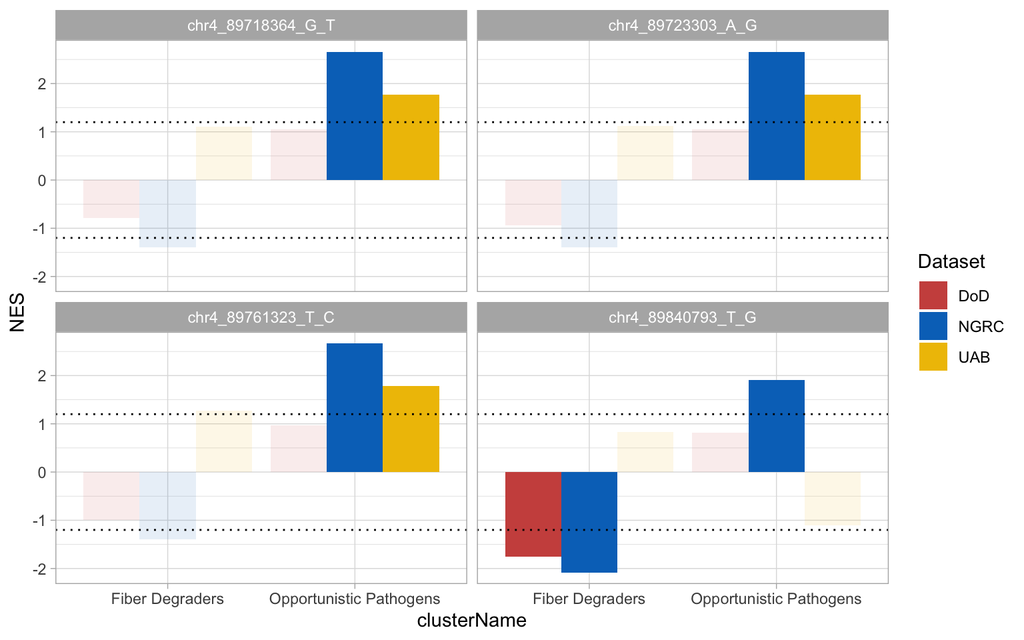

```r
tmp <- approach2_linda_MSEA %>%
  lapply(filter, padj < 0.1) %>%
  reduce(full_join, by = c("clusterName", "snp_variant"))

# restrict to rows that have at least 2 datasets replicated
# that is the row must contain between 0 and 1 NAs
associations_replic <- tmp[rowSums(is.na(select(tmp, contains("NES")))) < 2,]


MSEA_intersection_also_nonsignif <- approach2_linda_MSEA %>%
  lapply(filter, snp_variant %in% associations_replic$snp_variant, clusterName %in% associations_replic$clusterName) %>%
  reduce(rbind.data.frame) %>%
  mutate(alpha = ifelse(padj < 0.1, 1, 0.5))

NES_barplot <- ggplot(MSEA_intersection_also_nonsignif, aes(x = clusterName, y = NES, fill = Dataset)) +
  geom_col(position = position_dodge(), mapping = aes(alpha = alpha)) +
facet_wrap(~snp_variant) +
  theme_light() +
  geom_hline(yintercept = 1.2, col = "black", lty = "dotted") +
  geom_hline(yintercept = -1.2, col = "black", lty = "dotted") +
  guides(alpha = "none") +
  scale_fill_manual(values = ggsci::pal_jco()(4)[c(4,1,2)])

NES_barplot
```

# 2 Variant effect on PD

## 2.1 Approach 1 - Clusters abundance

```r
approach1_interaction_raw_results <- list(
  DoD = read_tsv("output_DoD/Q2/01_lm_dosage_in_PD.tsv") %>% mutate(Dataset = "DoD"),
  NGRC = read_tsv("output_NGRC/Q2/01_lm_dosage_in_PD.tsv") %>% mutate(Dataset = "NGRC"),
  UAB = read_tsv("output_UAB/Q2/01_lm_dosage_in_PD.tsv") %>% mutate(Dataset = "UAB")
) %>%
  lapply(relocate, Dataset) %>%
  lapply(filter, grepl(":", term))
```

### 2.1.1 Significance based on Bonferroni-adjusted P-values

No interaction term was ever significant accounting for all independent tests as defined before ($N_{clusters} \times N_{indep.Variants}$).

```r
tmp <- lapply(approach1_interaction_raw_results, filter, p.adj_bonferroni < 0.1) %>%
  lapply(mutate_if, is.numeric, round, 4) %>%
  lapply(reactable, sortable = TRUE, filterable = TRUE)
```

```r
tmp$DoD
```

| Dataset | clusterName | variant | term | estimate | std.error | statistic | p.value | p.adj_bonferroni | significant |
| --- | --- | --- | --- | --- | --- | --- | --- | --- | --- |

```r
tmp$NGRC
```

| Dataset | clusterName | variant | term | estimate | std.error | statistic | p.value | p.adj_bonferroni | significant |
| --- | --- | --- | --- | --- | --- | --- | --- | --- | --- |

```r
tmp$UAB
```

| Dataset | clusterName | variant | term | estimate | std.error | statistic | p.value | p.adj_bonferroni | significant |
| --- | --- | --- | --- | --- | --- | --- | --- | --- | --- |

### 2.1.2 Conclusions of approach 1 (ClusterSum)

- Within dataset:
  - There were no variant associations with ClusterSums in each dataset, in any of the two significance thresholds chosen
- Across datasets:
  - There were not associations within dataset that could be discussed

## 2.2 Approach 2 - Regression of each microbe, followed by Microbe Set Enrichment analysis

### 2.2.1 LinDA association only

```r
approach2_interaction_linda <- list(
  DoD = read_tsv("output_DoD/Q2/02_LinDA_regression_dosage_in_PD.tsv") %>% mutate(Dataset = "DoD"),
  NGRC = read_tsv("output_NGRC/Q2/02_LinDA_regression_dosage_in_PD.tsv") %>% mutate(Dataset = "NGRC"),
  UAB = read_tsv("output_UAB/Q2/02_LinDA_regression_dosage_in_PD.tsv") %>% mutate(Dataset = "UAB")
) %>%
  lapply(relocate, Dataset) %>%
  lapply(filter, grepl("interactionPD", covariate))
```

```r
tables_as_list <- approach2_interaction_linda %>%
  lapply(filter, padj < 0.1) %>%
  lapply(mutate_if, is.numeric, round, 4) %>%
  lapply(select, -lfcSE, -reject, -df, -covariate) %>%
  lapply(reactable, sortable = TRUE, filterable = TRUE)
```

```r
tables_as_list$DoD
```

| Dataset | variantName | taxon | baseMean | log2FoldChange | stat | pvalue | padj |
| --- | --- | --- | --- | --- | --- | --- | --- |

```r
tables_as_list$NGRC
```

| Dataset | variantName | taxon | baseMean | log2FoldChange | stat | pvalue | padj |
| --- | --- | --- | --- | --- | --- | --- | --- |

```r
tables_as_list$UAB
```

| Dataset | variantName | taxon | baseMean | log2FoldChange | stat | pvalue | padj |
| --- | --- | --- | --- | --- | --- | --- | --- |

Are there cases where the same variant association term in PD is significantly associated with the same bacterium in more than one dataset?

```r
tmp <- approach2_interaction_linda %>%
  lapply(filter, padj < 0.1) %>%
  reduce(full_join, by = c("taxon", "variantName"))

associations_replic <- tmp[rowSums(is.na(select(tmp, contains("log2FoldChange")))) < 2,]

linda_intersection_also_nonsignif <- approach2_interaction_linda %>%
  lapply(filter, variantName %in% associations_replic$variantName, taxon %in% associations_replic$taxon) %>%
  reduce(rbind.data.frame) %>%
  mutate(alpha = ifelse(padj < 0.1, 1, 0.5))

reactable(linda_intersection_also_nonsignif)
```

| Dataset | variantName | covariate | taxon | baseMean | log2FoldChange | lfcSE | stat | pvalue | padj | reject | df | alpha |
| --- | --- | --- | --- | --- | --- | --- | --- | --- | --- | --- | --- | --- |

### 2.2.2 Microbe Set Enrichment Analysis with LinDA `statistic`s

```r
approach2_linda_MSEA <- list(
  DoD = read_tsv("output_DoD/Q2/03_full_MSEA_results_variant_in_PD.tsv") %>% mutate(Dataset = "DoD"),
  NGRC = read_tsv("output_NGRC/Q2/03_full_MSEA_results_variant_in_PD.tsv") %>% mutate(Dataset = "NGRC"),
  UAB = read_tsv("output_UAB/Q2/03_full_MSEA_results_variant_in_PD.tsv") %>% mutate(Dataset = "UAB")
) %>%
  lapply(relocate, Dataset)
```

Below is the table of union of Microbe sets enriched or depleted across the three datasets.

```r
approach2_linda_MSEA  %>%
  lapply(filter, padj < 0.1) %>%
  lapply(select, -leadingEdge) %>%
  reduce(full_join, by = c("clusterName", "snp_variant")) %>%
  mutate_if(is.numeric, round, 4) %>%
  reactable()
```

| Dataset.x | snp_variant | clusterName | pval.x | padj.x | log2err.x | ES.x | NES.x | size.x | Dataset.y | pval.y | padj.y | log2err.y | ES.y | NES.y | size.y | Dataset | pval | padj | log2err | ES | NES | size |
| --- | --- | --- | --- | --- | --- | --- | --- | --- | --- | --- | --- | --- | --- | --- | --- | --- | --- | --- | --- | --- | --- | --- |
| DoD | chr4_89587189_T_G | Fiber Degraders | 0.0106 | 0.0634 | 0.3807 | -0.5106 | -1.7056 | 16 | NA | NA | NA | NA | NA | NA | NA | UAB | 0.005 | 0.0303 | 0.407 | -0.6184 | -1.8091 | 16 |
| DoD | chr4_89718364_G_T | Bifidobacteria | 0.0019 | 0.0113 | 0.4551 | 0.8143 | 1.9299 | 7 | NA | NA | NA | NA | NA | NA | NA | NA | NA | NA | NA | NA | NA | NA |
| DoD | chr4_89723303_A_G | Bifidobacteria | 0.0028 | 0.0167 | 0.4317 | 0.82 | 1.9543 | 7 | NA | NA | NA | NA | NA | NA | NA | NA | NA | NA | NA | NA | NA | NA |
| DoD | chr4_89761323_T_C | Bifidobacteria | 0.0003 | 0.002 | 0.4985 | 0.8515 | 2.0113 | 7 | NA | NA | NA | NA | NA | NA | NA | NA | NA | NA | NA | NA | NA | NA |
| DoD | chr6_32602640_A_C | Fiber Degraders | 0.0029 | 0.0175 | 0.4317 | -0.637 | -1.801 | 16 | NA | NA | NA | NA | NA | NA | NA | NA | NA | NA | NA | NA | NA | NA |
| DoD | chr6_32604184_T_C | Fiber Degraders | 0.0027 | 0.0163 | 0.4317 | -0.6403 | -1.8056 | 16 | NA | NA | NA | NA | NA | NA | NA | NA | NA | NA | NA | NA | NA | NA |
| DoD | chr6_32684419_T_C | Fiber Degraders | 0.0142 | 0.0852 | 0.3807 | -0.6227 | -1.6367 | 16 | NA | NA | NA | NA | NA | NA | NA | NA | NA | NA | NA | NA | NA | NA |
| DoD | chr6_32698883_C_T | Fiber Degraders | 0.0003 | 0.0019 | 0.4985 | -0.7254 | -2.0067 | 16 | NGRC | 0.011 | 0.0658 | 0.3807 | 0.6351 | 1.5921 | 16 | NA | NA | NA | NA | NA | NA | NA |
| NA | chr4_89587189_T_G | Opportunistic Pathogens | NA | NA | NA | NA | NA | NA | NGRC | 0.0153 | 0.0916 | 0.3807 | 0.5546 | 1.7341 | 18 | NA | NA | NA | NA | NA | NA | NA |
| NA | chr4_89685975_C_G | Opportunistic Pathogens | NA | NA | NA | NA | NA | NA | NGRC | 0.0001 | 0.0007 | 0.5384 | -0.7055 | -2.137 | 18 | NA | NA | NA | NA | NA | NA | NA |

[output cut: 36 more lines]

To better view the degree of replication, let’s plot all and show where FDR q-values are less than 0.1.

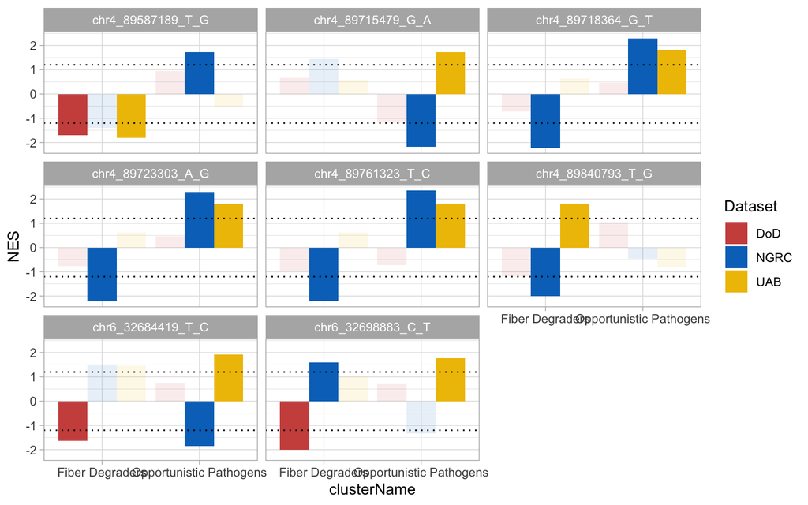

```r
tmp <- approach2_linda_MSEA %>%
  lapply(filter, padj < 0.1) %>%
  reduce(full_join, by = c("clusterName", "snp_variant"))

# restrict to rows that have at least 2 datasets replicated
# that is the row must contain between 0 and 1 NAs
associations_replic <- tmp[rowSums(is.na(select(tmp, contains("NES")))) < 2,]


MSEA_intersection_also_nonsignif <- approach2_linda_MSEA %>%
  lapply(filter, snp_variant %in% associations_replic$snp_variant, clusterName %in% associations_replic$clusterName) %>%
  reduce(rbind.data.frame) %>%
  mutate(alpha = ifelse(padj < 0.1, 1, 0.5))

NES_barplot <- ggplot(MSEA_intersection_also_nonsignif, aes(x = clusterName, y = NES, fill = Dataset)) +
  geom_col(position = position_dodge(), mapping = aes(alpha = alpha)) +
facet_wrap(~snp_variant) +
  theme_light() +
  geom_hline(yintercept = 1.2, col = "black", lty = "dotted") +
  geom_hline(yintercept = -1.2, col = "black", lty = "dotted") +
  guides(alpha = "none") +
  scale_fill_manual(values = ggsci::pal_jco()(4)[c(4,1,2)])

NES_barplot
```

# 3 Variant effect on Controls (NHC)

## 3.1 Approach 1 - Clusters abundance

```r
approach1_interaction_raw_results <- list(
  DoD = read_tsv("output_DoD/Q3/01_lm_dosage_in_Controls.tsv") %>% mutate(Dataset = "DoD"),
  NGRC = read_tsv("output_NGRC/Q3/01_lm_dosage_in_Controls.tsv") %>% mutate(Dataset = "NGRC"),
  UAB = read_tsv("output_UAB/Q3/01_lm_dosage_in_Controls.tsv") %>% mutate(Dataset = "UAB")
) %>%
  lapply(relocate, Dataset) %>%
  lapply(filter, grepl(":", term))
```

### 3.1.1 Significance based on Bonferroni-adjusted P-values

No interaction term was ever significant accounting for all independent tests as defined before ($N_{clusters} \times N_{indep.Variants}$).

```r
tmp <- lapply(approach1_interaction_raw_results, filter, p.adj_bonferroni < 0.1) %>%
  lapply(mutate_if, is.numeric, round, 4) %>%
  lapply(reactable, sortable = TRUE, filterable = TRUE)
```

```r
tmp$DoD
```

| Dataset | clusterName | variant | term | estimate | std.error | statistic | p.value | p.adj_bonferroni | significant |
| --- | --- | --- | --- | --- | --- | --- | --- | --- | --- |

```r
tmp$NGRC
```

| Dataset | clusterName | variant | term | estimate | std.error | statistic | p.value | p.adj_bonferroni | significant |
| --- | --- | --- | --- | --- | --- | --- | --- | --- | --- |

```r
tmp$UAB
```

| Dataset | clusterName | variant | term | estimate | std.error | statistic | p.value | p.adj_bonferroni | significant |
| --- | --- | --- | --- | --- | --- | --- | --- | --- | --- |

### 3.1.2 Conclusions of approach 1 (ClusterSum)

- Within dataset:
  - There were no Bonferroni-adjusted interaction associations
- Across datasets:
  - No overlap of the few associations marginally significant considering raw p-values.

## 3.2 Approach 2 - Regression of each microbe, followed by Microbe Set Enrichment analysis

### 3.2.1 LinDA association only

```r
approach2_interaction_linda <- list(
  DoD = read_tsv("output_DoD/Q3/02_LinDA_regression_dosage_in_Controls.tsv") %>% mutate(Dataset = "DoD"),
  NGRC = read_tsv("output_NGRC/Q3/02_LinDA_regression_dosage_in_Controls.tsv") %>% mutate(Dataset = "NGRC"),
  UAB = read_tsv("output_UAB/Q3/02_LinDA_regression_dosage_in_Controls.tsv") %>% mutate(Dataset = "UAB")
) %>%
  lapply(relocate, Dataset) %>%
  lapply(filter, grepl("interactionPD", covariate))
```

```r
tables_as_list <- approach2_interaction_linda %>%
  lapply(filter, padj < 0.1) %>%
  lapply(mutate_if, is.numeric, round, 4) %>%
  lapply(select, -lfcSE, -reject, -df, -covariate) %>%
  lapply(reactable, sortable = TRUE, filterable = TRUE)
```

```r
tables_as_list$DoD
```

| Dataset | variantName | taxon | baseMean | log2FoldChange | stat | pvalue | padj |
| --- | --- | --- | --- | --- | --- | --- | --- |

```r
tables_as_list$NGRC
```

| Dataset | variantName | taxon | baseMean | log2FoldChange | stat | pvalue | padj |
| --- | --- | --- | --- | --- | --- | --- | --- |

```r
tables_as_list$UAB
```

| Dataset | variantName | taxon | baseMean | log2FoldChange | stat | pvalue | padj |
| --- | --- | --- | --- | --- | --- | --- | --- |

Are there cases where the same variant:PD interaction term is significantly associated with the same bacterium in more than one dataset?

```r
tmp <- approach2_interaction_linda %>%
  lapply(filter, padj < 0.1) %>%
  reduce(full_join, by = c("taxon", "variantName"))

associations_replic <- tmp[rowSums(is.na(select(tmp, contains("log2FoldChange")))) < 2,]

linda_intersection_also_nonsignif <- approach2_interaction_linda %>%
  lapply(filter, variantName %in% associations_replic$variantName, taxon %in% associations_replic$taxon) %>%
  reduce(rbind.data.frame) %>%
  mutate(alpha = ifelse(padj < 0.1, 1, 0.5))

reactable(linda_intersection_also_nonsignif)
```

| Dataset | variantName | covariate | taxon | baseMean | log2FoldChange | lfcSE | stat | pvalue | padj | reject | df | alpha |
| --- | --- | --- | --- | --- | --- | --- | --- | --- | --- | --- | --- | --- |

### 3.2.2 Microbe Set Enrichment Analysis with LinDA `statistic`s

```r
approach2_linda_MSEA <- list(
  DoD = read_tsv("output_DoD/Q3/03_full_MSEA_results_variant_in_Controls.tsv") %>% mutate(Dataset = "DoD"),
  NGRC = read_tsv("output_NGRC/Q3/03_full_MSEA_results_variant_in_Controls.tsv") %>% mutate(Dataset = "NGRC"),
  UAB = read_tsv("output_UAB/Q3/03_full_MSEA_results_variant_in_Controls.tsv") %>% mutate(Dataset = "UAB")
) %>%
  lapply(relocate, Dataset)
```

Below is the table of union of Microbe sets enriched or depleted across the three datasets.

```r
approach2_linda_MSEA  %>%
  lapply(filter, padj < 0.1) %>%
  lapply(select, -leadingEdge) %>%
  reduce(full_join, by = c("clusterName", "snp_variant")) %>%
  mutate_if(is.numeric, round, 4) %>%
  reactable()
```

| Dataset.x | snp_variant | clusterName | pval.x | padj.x | log2err.x | ES.x | NES.x | size.x | Dataset.y | pval.y | padj.y | log2err.y | ES.y | NES.y | size.y | Dataset | pval | padj | log2err | ES | NES | size |
| --- | --- | --- | --- | --- | --- | --- | --- | --- | --- | --- | --- | --- | --- | --- | --- | --- | --- | --- | --- | --- | --- | --- |
| DoD | chr4_89685975_C_G | Bifidobacteria | 0.0013 | 0.0067 | 0.4551 | 0.9039 | 1.8321 | 4 | NA | NA | NA | NA | NA | NA | NA | NA | NA | NA | NA | NA | NA | NA |
| DoD | chr4_89685975_C_G | Fiber Degraders | 0.003 | 0.0075 | 0.4317 | -0.6411 | -1.7439 | 16 | NGRC | 0.0004 | 0.0011 | 0.4985 | 0.6853 | 2.0353 | 16 | NA | NA | NA | NA | NA | NA | NA |
| DoD | chr4_89715479_G_A | Fiber Degraders | 0.0039 | 0.0195 | 0.4317 | -0.6294 | -1.7993 | 16 | NGRC | 0.0005 | 0.0014 | 0.4985 | 0.6975 | 2.0351 | 16 | NA | NA | NA | NA | NA | NA | NA |
| DoD | chr4_89716450_G_A | Bifidobacteria | 0.0132 | 0.033 | 0.3807 | 0.845 | 1.735 | 4 | NA | NA | NA | NA | NA | NA | NA | NA | NA | NA | NA | NA | NA | NA |
| DoD | chr4_89716450_G_A | Fiber Degraders | 0.0078 | 0.033 | 0.407 | -0.63 | -1.7045 | 16 | NGRC | 0.0052 | 0.0155 | 0.407 | 0.6189 | 1.775 | 16 | NA | NA | NA | NA | NA | NA | NA |
| DoD | chr4_89716450_G_A | Strepto-Actino | 0.0242 | 0.0403 | 0.3525 | 0.7126 | 1.7279 | 6 | NA | NA | NA | NA | NA | NA | NA | NA | NA | NA | NA | NA | NA | NA |
| DoD | chr4_89720189_T_C | Bifidobacteria | 0.0286 | 0.0476 | 0.3525 | 0.8245 | 1.688 | 4 | NA | NA | NA | NA | NA | NA | NA | NA | NA | NA | NA | NA | NA | NA |
| DoD | chr4_89720189_T_C | Fiber Degraders | 0.0066 | 0.0329 | 0.407 | -0.6291 | -1.6967 | 16 | NGRC | 0.0044 | 0.0132 | 0.407 | 0.616 | 1.7663 | 16 | NA | NA | NA | NA | NA | NA | NA |
| DoD | chr4_89720189_T_C | Strepto-Actino | 0.0186 | 0.0465 | 0.3525 | 0.7205 | 1.751 | 6 | NA | NA | NA | NA | NA | NA | NA | NA | NA | NA | NA | NA | NA | NA |
| DoD | chr4_89744890_C_T | Bifidobacteria | 0.0221 | 0.0371 | 0.3525 | 0.826 | 1.6878 | 4 | NA | NA | NA | NA | NA | NA | NA | NA | NA | NA | NA | NA | NA | NA |

[output cut: 32 more lines]

To better view the degree of replication, let’s plot all and show where FDR q-values are less than 0.1.

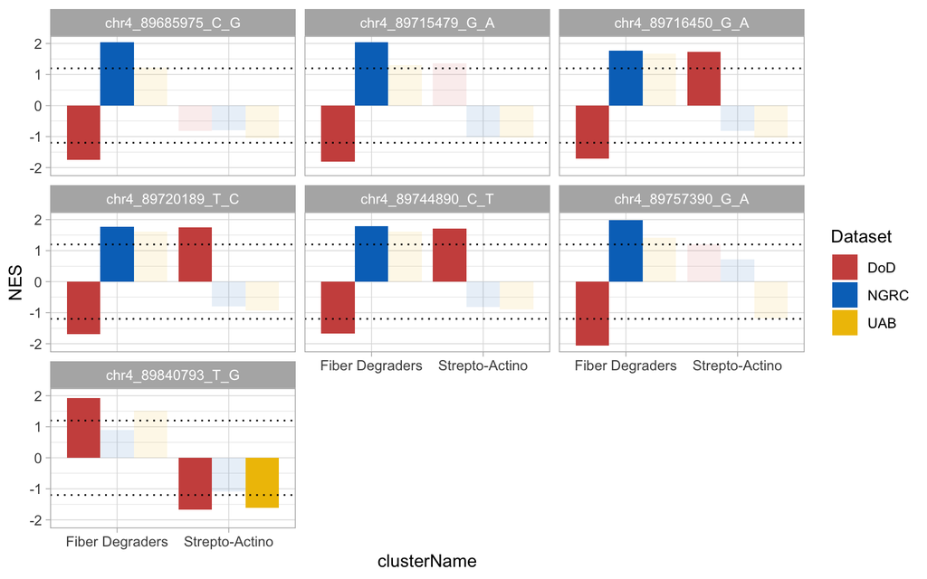

```r
tmp <- approach2_linda_MSEA %>%
  lapply(filter, padj < 0.1) %>%
  reduce(full_join, by = c("clusterName", "snp_variant"))

# restrict to rows that have at least 2 datasets replicated
# that is the row must contain between 0 and 1 NAs
associations_replic <- tmp[rowSums(is.na(select(tmp, contains("NES")))) < 2,]


MSEA_intersection_also_nonsignif <- approach2_linda_MSEA %>%
  lapply(filter, snp_variant %in% associations_replic$snp_variant, clusterName %in% associations_replic$clusterName) %>%
  reduce(rbind.data.frame) %>%
  mutate(alpha = ifelse(padj < 0.1, 1, 0.5))

NES_barplot <- ggplot(MSEA_intersection_also_nonsignif, aes(x = clusterName, y = NES, fill = Dataset)) +
  geom_col(position = position_dodge(), mapping = aes(alpha = alpha)) +
facet_wrap(~snp_variant) +
  theme_light() +
  geom_hline(yintercept = 1.2, col = "black", lty = "dotted") +
  geom_hline(yintercept = -1.2, col = "black", lty = "dotted") +
  guides(alpha = "none") +
  scale_fill_manual(values = ggsci::pal_jco()(4)[c(4,1,2)])

NES_barplot
```

# 4 Datasets uniformity check

```r
library(mia)
load("../Data/DoD_data.mae.RData")
load("../Data/NGRC_data.mae.RData")
load("../Data/UAB_data.mae.RData")

relabunds_summExp.list <- list(
  DoD = DoD_data.mae[["metaphlan_RelAbund.se"]],
  NGRC = NGRC_data.mae[["metaphlan_RelAbund.se"]],
  UAB = UAB_data.mae[["metaphlan_RelAbund.se"]]
)

relabunds_summExp.list$DoD$Dataset <- "DoD"
relabunds_summExp.list$NGRC$Dataset <- "NGRC"
relabunds_summExp.list$UAB$Dataset <- "UAB"

data_together.se <- mia::mergeSEs(relabunds_summExp.list, assay.type = "metaphlan_RelAbund")

NMDS.df <- getNMDS(data_together.se, assay.type = "metaphlan_RelAbund", name = "NMDS") %>%
  as.data.frame() %>%
  set_names(c("NMDS.1", "NMDS.2")) %>%
  rownames_to_column("SubjectID") %>%
  dplyr::full_join(as.data.frame(colData(data_together.se)), by = "SubjectID") %>%
  dplyr::full_join(
    as.data.frame(t(assay(data_together.se))) %>%
      rownames_to_column("SubjectID"),
    by = "SubjectID"
    )
```

```r
plot_colDataset <- ggplot(NMDS.df, aes(x = NMDS.1, y = NMDS.2, color = Dataset)) +
  geom_point() +
  scale_color_manual(values = c("skyblue4", "pink2", "green4")) +
  stat_ellipse() +
  theme_light() +
  theme(legend.position = "top")

plotcolPD <- ggplot(NMDS.df, aes(x = NMDS.1, y = NMDS.2, color = Case_status)) +
  geom_point() +
  scale_color_manual(values = c("steelblue3", "gold3")) +
  stat_ellipse() +
  theme_light() +
  theme(legend.position = "top")

plotcolStoolTravelTime <- ggplot(NMDS.df, aes(x = NMDS.1, y = NMDS.2, color = stool_travel_time)) +
  geom_point() +
  theme_light() +
  scale_color_viridis_c(direction = -1) +
  theme(legend.position = "top")

plotcolEcoli <- ggplot(NMDS.df, aes(x = NMDS.1, y = NMDS.2, color = s__Escherichia_coli)) +
  geom_point() +
  theme_light() +
  scale_color_viridis_c(direction = -1) +
  theme(legend.position = "top")
```

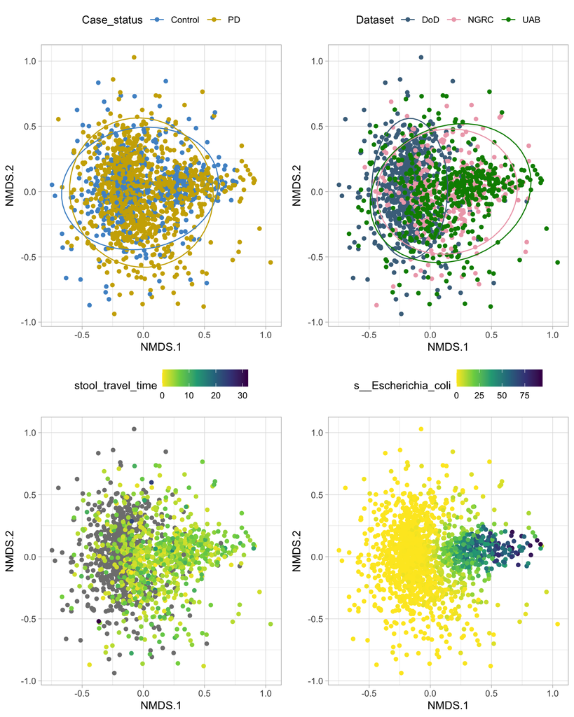

```r
ggarrange(plotcolPD, plot_colDataset,plotcolStoolTravelTime, plotcolEcoli)
```

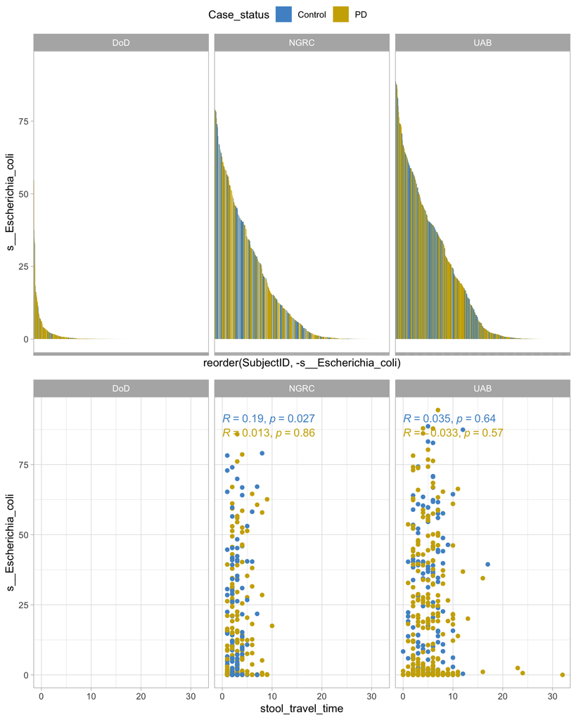

```r
ggarrange(
  ggplot(NMDS.df, aes(x = reorder(SubjectID, -s__Escherichia_coli), y = s__Escherichia_coli, fill = Case_status)) +
  geom_col() +
  theme_light() +
  scale_fill_manual(values = c("steelblue3", "gold3")) +
  facet_wrap(~ Dataset, scales = "free_x") +
  theme(axis.text.x = element_blank(), panel.grid = element_blank()),

ggplot(NMDS.df, aes(x = stool_travel_time, y = s__Escherichia_coli, color = Case_status)) +
  geom_point() +
  facet_wrap(~Dataset) +
  theme_light() +
  scale_color_manual(values = c("steelblue3", "gold3")) +
  stat_cor(method = "spearman", show.legend = FALSE),
ncol = 1,
nrow = 2,
common.legend = TRUE)
```